# Mapping the Collatz Conjecture

## Daniel Jordán

# Collatz Conjecture

### (a.k.a. "the $3x+1$ problem")

- Named after german mathematician Lothar Collatz
- Simple to explain, hard to proof

> *Starting from any positive integer, if even **divide by 2**, else **multiply by 3 and add 1**. Repeating this process converges any such number to 1.*

$\Large \begin{align*} x &= 8 \rightarrow 4 \rightarrow 2 \rightarrow 1 \\ x &= 3 \rightarrow 10 \rightarrow 5 \rightarrow 16 \rightarrow 8 \rightarrow 4 \rightarrow 2 \rightarrow 1 \\ x &= 17 \rightarrow 52 \rightarrow 26 \rightarrow 13 \rightarrow 40 \rightarrow 20 \rightarrow 10 \cdots \rightarrow 1 \end{align*}$

## Generalized Collatz Problem

> Starting from any positive integer, $x$,  
> if $x/d$ is an *integer* then divide by $d$,  
> else multiply by integer $a$ and add integer $b$.

$\Large \begin{align*} &\text{if d-even,} \quad x \leftarrow x/d \\ \quad \\ &\text{if d-odd,} \quad x \leftarrow ax + b \end{align*}$

# Convergence type: for all at same

## Parameters: $a=3$, $b=3$, $d=3$

$\Large \begin{align*} x &= 3 \rightarrow 1 \rightarrow 6 \rightarrow 2 \rightarrow 9 \rightarrow 3 \rightarrow 1 \\ x &= 4 \rightarrow 15 \rightarrow 5 \rightarrow 18 \rightarrow 6 \rightarrow 2 \rightarrow 9 \rightarrow 3 \rightarrow 1 \\ x &= 17 \rightarrow 54 \rightarrow 18 \rightarrow 6 \rightarrow 2 \rightarrow 9 \rightarrow 3 \rightarrow 1 \end{align*}$

# Convergence type: for all at different

## Parameters: $a=3$, $b=6$, $d=3$

$\Large \begin{align*} x &= 3 \rightarrow 1 \rightarrow 9 \rightarrow 3 \rightarrow 1 \\ x &= 4 \rightarrow 18 \rightarrow 6 \rightarrow 2 \rightarrow 12 \rightarrow 4 \\ x &= 17 \rightarrow 57 \rightarrow 19 \rightarrow 63 \rightarrow 21 \rightarrow 7 \cdots \rightarrow 1 \end{align*}$

# Convergence type: for some

## Parameters: $a=2$, $b=-2$, $d=3$

$\Large \begin{align*} x &= 3 \rightarrow 1 \rightarrow 0 \\ x &= 11 \rightarrow 20 \rightarrow 38 \rightarrow 74 \rightarrow \infty \\ \end{align*}$

# Convergence type: for none

## Parameters: $a=2$, $b= 3$, $d=3$

$\Large \begin{align*} x &= any \rightarrow \infty \\ \end{align*}$

# Collatz Map

For any given divisor, the "Collatz map" will be a plane of coordinates $(a, b)$:

| (-3,-3) | (-2, -3) | (-1, -3) | (0, -3) | (1, -3) | ... |
| --- | --- | --- | --- | --- | --- |
| (-3,-2) | (-2, -2) | (-1, -2) | (0, -2) | (1, -2) | ... |
| ... | ... | ... | ... | ... | ... |

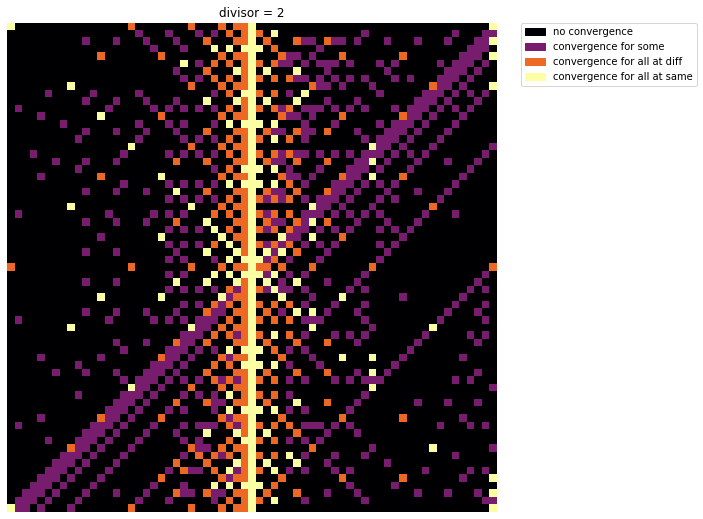

```python
collatz_plotter(collatz_map, div)
```

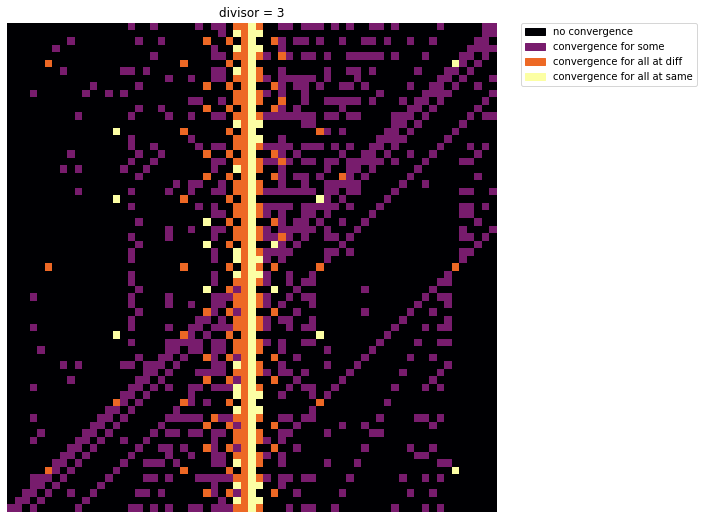

```python
collatz_plotter(collatz_map, div)
```

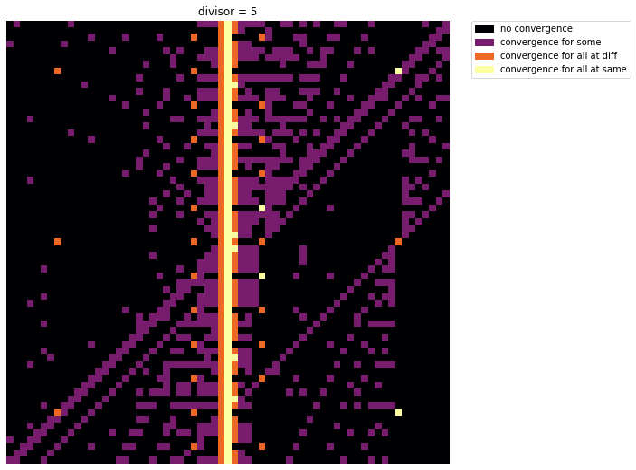

```python
collatz_plotter(collatz_map, div)
```

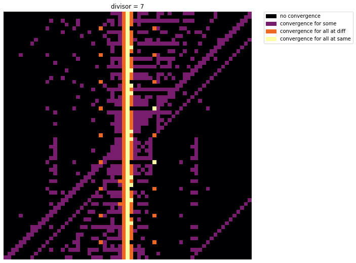

```python
collatz_plotter(collatz_map, div)
```

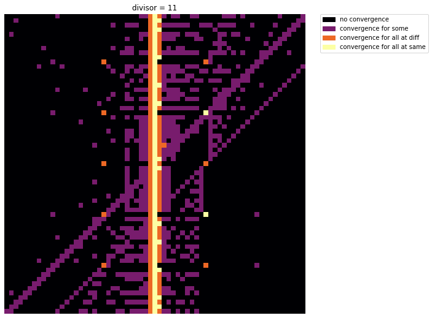

```python
collatz_plotter(collatz_map, div)
```

# Thank you!

Project available at:

github.com/danj7/Collatz-Mapper